# EDA: SiMWiSense: Simultaneous Multi-Subject Activity Classification Through Wi-Fi Signals

- Dataport: https://ieee-dataport.org/documents/dataset-simultaneous-multi-subject-activity-classification-through-wi-fi-signals

Equipe: Nobuko e Diogo

Maio/2025

Resumo do notebook

# Explicabilidade está relacionada amostra e ao modelo

- O SiMWisense apresenta resultados de *96 modelos no artigo.
- Mas que modelo escolher?

# 00-build-models.sh

```
#!/bin/sh

pushd .

cd ../Python_Code

# Figure 3 - Classification accuracy as function of sensing proximity. (18 models)
python baseline_proximity.py Classroom m1 m1 Classroom_m1_m1.h5 242
python baseline_proximity.py Classroom m1 m2 Classroom_m1_m2.h5 242
python baseline_proximity.py Classroom m1 m3 Classroom_m1_m3.h5 242
python baseline_proximity.py Classroom m2 m1 Classroom_m2_m1.h5 242
python baseline_proximity.py Classroom m2 m2 Classroom_m2_m2.h5 242
python baseline_proximity.py Classroom m2 m3 Classroom_m2_m3.h5 242
python baseline_proximity.py Classroom m3 m1 Classroom_m3_m1.h5 242
python baseline_proximity.py Classroom m3 m2 Classroom_m3_m2.h5 242
python baseline_proximity.py Classroom m3 m3 Classroom_m3_m3.h5 242
python baseline_proximity.py Office m1 m1 Office_m1_m1.h5 242
python baseline_proximity.py Office m1 m2 Office_m1_m2.h5 242
python baseline_proximity.py Office m1 m3 Office_m1_m3.h5 242
python baseline_proximity.py Office m2 m1 Office_m2_m1.h5 242
python baseline_proximity.py Office m2 m2 Office_m2_m2.h5 242
python baseline_proximity.py Office m2 m3 Office_m2_m3.h5 242
python baseline_proximity.py Office m3 m1 Office_m3_m1.h5 242
python baseline_proximity.py Office m3 m2 Office_m3_m2.h5 242
python baseline_proximity.py Office m3 m3 Office_m3_m3.h5 242

# Figure 11: Subject identification in SiMWiSense with baseline CNN (6 models)
python baseline_coarse.py Classroom m1 Classroom m1 Classroom_m1_Classroom_m1_242.h5 242
python baseline_coarse.py Classroom m2 Classroom m2 Classroom_m2_Classroom_m2_242.h5 242
python baseline_coarse.py Classroom m3 Classroom m3 Classroom_m3_Classroom_m3_242.h5 242
python baseline_coarse.py Office m1 Office m1 Office_m1_Office_m1_242.h5 242
python baseline_coarse.py Office m2 Office m2 Office_m2_Office_m2_242.h5 242
python baseline_coarse.py Office m3 Office m3 Office_m3_Office_m3_242.h5 242

# Figure 12: Performance of SiMWiSense at three different environments with baseline CNN. (6 models)
python baseline_coarse.py Classroom m1 Classroom m1 Classroom_m1_Classroom_m1_242.h5 242
python baseline_coarse.py Classroom m2 Classroom m2 Classroom_m2_Classroom_m2_242.h5 242
python baseline_coarse.py Classroom m3 Classroom m3 Classroom_m3_Classroom_m3_242.h5 242
python baseline_coarse.py Office m1 Office m1 Office_m1_Office_m1_242.h5 242
python baseline_coarse.py Office m2 Office m2 Office_m2_Office_m2_242.h5 242
python baseline_coarse.py Office m3 Office m3 Office_m3_Office_m3_242.h5 242

# Figure 13: Performance of SiMWiSense with baseline CNN as a function of number of subcarriers (environment: classroom). (12 models)
python baseline_fine_grained.py Classroom m1 Classroom m1 Classroom_m1_Classroom_m1_20.h5 20
python baseline_fine_grained.py Classroom m1 Classroom m1 Classroom_m1_Classroom_m1_40.h5 40
python baseline_fine_grained.py Classroom m1 Classroom m1 Classroom_m1_Classroom_m1_80.h5 80
python baseline_fine_grained.py Classroom m1 Classroom m1 Classroom_m1_Classroom_m1_160.h5 160
python baseline_fine_grained.py Classroom m2 Classroom m2 Classroom_m2_Classroom_m2_20.h5 20
python baseline_fine_grained.py Classroom m2 Classroom m2 Classroom_m2_Classroom_m2_40.h5 40
python baseline_fine_grained.py Classroom m2 Classroom m2 Classroom_m2_Classroom_m2_80.h5 80
python baseline_fine_grained.py Classroom m2 Classroom m2 Classroom_m2_Classroom_m2_160.h5 160
python baseline_fine_grained.py Classroom m3 Classroom m3 Classroom_m3_Classroom_m3_20.h5 20
python baseline_fine_grained.py Classroom m3 Classroom m3 Classroom_m3_Classroom_m3_40.h5 40
python baseline_fine_grained.py Classroom m3 Classroom m3 Classroom_m3_Classroom_m3_80.h5 80
python baseline_fine_grained.py Classroom m3 Classroom m3 Classroom_m3_Classroom_m3_160.h5 160

# Figure 15: Performance of FREL in simultaneous activity sensing with new untrained environments.
python baseline_fine_grained.py Classroom m1 Office m1 Classroom_m1_Office_m1_242.h5 242
python baseline_fine_grained.py Classroom m2 Office m2 Classroom_m2_Office_m2_242.h5 242
python baseline_fine_grained.py Classroom m3 Office m3 Classroom_m3_Office_m3_242.h5 242
python baseline_fine_grained.py Office m1 Classroom m1 Office_m1_Classroom_m1_242.h5 242
python baseline_fine_grained.py Office m2 Classroom m2 Office_m2_Classroom_m2_242.h5 242
python baseline_fine_grained.py Office m3 Classroom m3 Office_m3_Classroom_m3_242.h5 242
# faltam modelos FREL (mais 6)

# Figure 16: Performance comparison of FREL with FSEL in new untrained environments. (12 models)

# Figure 18: Performance of FREL as the subject identifier in untrained environments. (12 models)

# Figure 19: Performance comparison of FREL and FSEL as the subject identifier in untrained environments (12 models)

# Figure 20: Performance of FREL with new untrained monitors. (12 models).






popd
```

# Os modelos não são grandes

```python
!find ../Data -type d -name "m?" | while read dir; do     count=$(find "$dir" -maxdepth 1 -name '*.h5' | wc -l);     total_bytes=$(find "$dir" -maxdepth 1 -name '*.h5' -exec du -bc {} + | grep total$ | awk '{print $1}');     if [ "$count" -gt 0 ]; then         avg_bytes=$((total_bytes / count));         avg_human=$(numfmt --to=iec --suffix=B "$avg_bytes");         total_human=$(numfmt --to=iec --suffix=B "$total_bytes");     else         avg_human="N/A";         total_human="0B";     fi;     BLUE='\033[1;34m';     GREEN='\033[1;32m';     YELLOW='\033[1;33m';     MAGENTA='\033[1;35m';     NC='\033[0m' ;     echo -e "${BLUE}$dir${NC} -> ${GREEN}$count arquivos${NC}, ${YELLOW}Total: $total_human${NC}, ${MAGENTA}Média: $avg_human${NC}"; done
```

```
../Data/coarse/Classroom/80MHz/3mo/m2 -> 1 arquivos, Total: 5,7MB, Média: 5,7MB
../Data/coarse/Classroom/80MHz/3mo/m3 -> 1 arquivos, Total: 5,7MB, Média: 5,7MB
../Data/coarse/Classroom/80MHz/3mo/m1 -> 1 arquivos, Total: 5,7MB, Média: 5,7MB
../Data/coarse/Office/80MHz/3mo/m2 -> 1 arquivos, Total: 5,7MB, Média: 5,7MB
../Data/coarse/Office/80MHz/3mo/m3 -> 1 arquivos, Total: 5,7MB, Média: 5,7MB
../Data/coarse/Office/80MHz/3mo/m1 -> 1 arquivos, Total: 5,7MB, Média: 5,7MB
../Data/proximity/Classroom/80MHz/3mo/m2 -> 3 arquivos, Total: 68MB, Média: 23MB
../Data/proximity/Classroom/80MHz/3mo/m3 -> 3 arquivos, Total: 68MB, Média: 23MB
../Data/proximity/Classroom/80MHz/3mo/m1 -> 3 arquivos, Total: 68MB, Média: 23MB
../Data/proximity/Office/80MHz/3mo/m2 -> 3 arquivos, Total: 68MB, Média: 23MB
../Data/proximity/Office/80MHz/3mo/m3 -> 3 arquivos, Total: 68MB, Média: 23MB
../Data/proximity/Office/80MHz/3mo/m1 -> 3 arquivos, Total: 68MB, Média: 23MB
../Data/fine_grained/Classroom/80MHz/3mo/m2 -> 4 arquivos, Total: 32MB, Média: 8,0MB
../Data/fine_grained/Classroom/80MHz/3mo/m3 -> 4 arquivos, Total: 32MB, Média: 8,0MB
../Data/fine_grained/Classroom/80MHz/3mo/m1 -> 5 arquivos, Total: 55MB, Média: 11MB
../Data/fine_grained/Office/80MHz/3mo/m2 -> 0 arquivos, Total: 0B, Média: N/A
../Data/fine_grained/Office/80MHz/3mo/m3 -> 0 arquivos, Total: 0B, Média: N/A
../Data/fine_grained/Office/80MHz/3mo/m1 -> 0 arquivos, Total: 0B, Média: N/A
```

# Reproduzindo avaliação da primeira tarefa: **proximity**

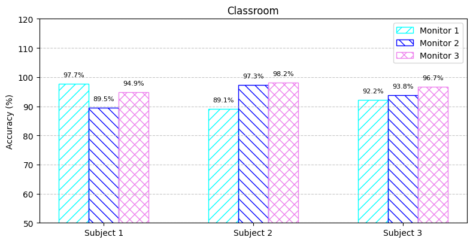

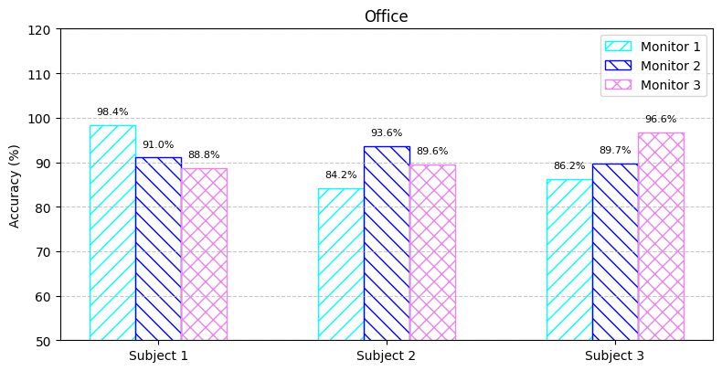

```python
import pandas as pd
results_df = pd.read_csv('SAIDAS/01-results_proximity.csv')

def plot_accuracy(environment):
  df = results_df.query(f"environment=='{environment}'")

  # Configurações
  subjects = ['m1', 'm2', 'm3']
  monitors = ['m1', 'm2', 'm3']
  hatches = ['//', '\\\\', 'xx']  # Padrões de hachura
  colors = ['cyan', 'blue', 'violet']  # Cores de contorno
  bar_width = 0.2

  x = np.arange(len(subjects))  # posições dos subjects

  fig, ax = plt.subplots(figsize=(8, 4))

  # Plot
  for i, monitor in enumerate(monitors):
      accuracies = df[df['data_from'] == monitor]['final_accuracy'] * 100  # porcentagem
      bars = ax.bar(x + i*bar_width, accuracies, width=bar_width, label=f'Monitor {i+1}',
                    hatch=hatches[i], color='none', edgecolor=colors[i])

      # Adicionar o valor percentual acima de cada barra
      for bar in bars:
          height = bar.get_height()
          ax.text(bar.get_x() + bar.get_width()/2, height + 2, f'{height:.1f}%',
                  ha='center', va='bottom', fontsize=8)

  # Customizações
  ax.set_ylabel('Accuracy (%)')
  ax.set_xticks(x + bar_width)
  ax.set_xticklabels(['Subject 1', 'Subject 2', 'Subject 3'])
  ax.legend()
  ax.set_ylim(50, 120)
  ax.grid(axis='y', linestyle='--', alpha=0.7)

  plt.tight_layout()
  plt.title(environment)
  plt.show()

plot_accuracy('Classroom')
plot_accuracy('Office')
```

O artigo tem outros números

> Figure 3 confirms our intuition. For example, it shows that in the **classroom** environment, the accuracy of Subject 1 is **95% from the CSI data of Monitor 1** whereas, with the exact same setup and tests, the accuracy of **Subject 2 and Subject 3 decreases by 30% on an average with Monitor 1**. This is because they are comparatively farther away from Subject 1 and more prone to the noises created by the other subjects at that instant. However, their performances improve drastically to **96% and 97%** when we consider CSI Monitor 2 and CSI Monitor 3 for Subject 2 and Subject 3 respectively. The other two environments follow similar trends. This clearly demonstrates that the CSI monitor closest to the subject performs better than other CSI monitors.

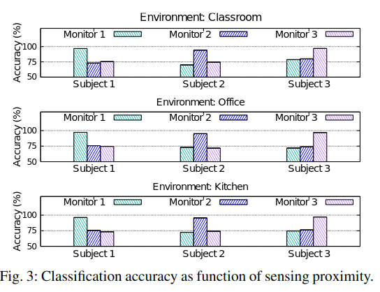

# Gradcam

## Baseado no código do

1. Grad-CAM class activation visualization no Keras (do François Chollet) (5anos atrás)
2. (https://github.com/ismailuddin/gradcam-tensorflow-2) (5anos atrás)
- Um exemplo por vez. (batch=1)
- Talvez dê para otimizar um pouco.

```python
gradcam_proximity_summary = pd.read_csv('SAIDAS/03-csv_summary_gradcam_proximity.csv')
gradcam_proximity_summary
```

|  | test | environment | monitor | slot | csv_file_path | elapsed_time_seconds |
| --- | --- | --- | --- | --- | --- | --- |
| 0 | proximity | Classroom | m1 | Test_m1 | ../Data/proximity/Classroom/80MHz/3mo/m1/Slots... | 507.651038 |
| 1 | proximity | Classroom | m1 | Test_m2 | ../Data/proximity/Classroom/80MHz/3mo/m1/Slots... | 503.202627 |
| 2 | proximity | Classroom | m1 | Test_m3 | ../Data/proximity/Classroom/80MHz/3mo/m1/Slots... | 491.408673 |
| 3 | proximity | Classroom | m2 | Test_m1 | ../Data/proximity/Classroom/80MHz/3mo/m2/Slots... | 538.526809 |
| 4 | proximity | Classroom | m2 | Test_m2 | ../Data/proximity/Classroom/80MHz/3mo/m2/Slots... | 495.169215 |
| 5 | proximity | Classroom | m2 | Test_m3 | ../Data/proximity/Classroom/80MHz/3mo/m2/Slots... | 487.401974 |
| 6 | proximity | Classroom | m3 | Test_m1 | ../Data/proximity/Classroom/80MHz/3mo/m3/Slots... | 540.595021 |
| 7 | proximity | Classroom | m3 | Test_m2 | ../Data/proximity/Classroom/80MHz/3mo/m3/Slots... | 504.182124 |
| 8 | proximity | Classroom | m3 | Test_m3 | ../Data/proximity/Classroom/80MHz/3mo/m3/Slots... | 512.920758 |
| 9 | proximity | Office | m1 | Test_m1 | ../Data/proximity/Office/80MHz/3mo/m1/Slots/Te... | 843.003301 |
| 10 | proximity | Office | m1 | Test_m2 | ../Data/proximity/Office/80MHz/3mo/m1/Slots/Te... | 832.684785 |
| 11 | proximity | Office | m1 | Test_m3 | ../Data/proximity/Office/80MHz/3mo/m1/Slots/Te... | 936.773924 |
| 12 | proximity | Office | m2 | Test_m1 | ../Data/proximity/Office/80MHz/3mo/m2/Slots/Te... | 957.633713 |
| 13 | proximity | Office | m2 | Test_m2 | ../Data/proximity/Office/80MHz/3mo/m2/Slots/Te... | 980.024743 |
| 14 | proximity | Office | m2 | Test_m3 | ../Data/proximity/Office/80MHz/3mo/m2/Slots/Te... | 958.352370 |
| 15 | proximity | Office | m3 | Test_m1 | ../Data/proximity/Office/80MHz/3mo/m3/Slots/Te... | 990.805768 |
| 16 | proximity | Office | m3 | Test_m2 | ../Data/proximity/Office/80MHz/3mo/m3/Slots/Te... | 956.201974 |
| 17 | proximity | Office | m3 | Test_m3 | ../Data/proximity/Office/80MHz/3mo/m3/Slots/Te... | 961.774823 |

```python
total_seconds = int(gradcam_proximity_summary['elapsed_time_seconds'].sum())
# total em hour, minutes, seconds
total_hours = total_seconds // 3600
total_seconds %= 3600
total_minutes = total_seconds // 60
total_seconds %= 60
total_time = f"{total_hours:02}:{total_minutes:02}:{total_seconds:02}"
print(f"Total time: {total_time}")
```

```
Total time: 03:36:38
```

```python
!du -sch ../GradCam/proximity
```

```
25G	../GradCam/proximity
25G	total
```

```python
!find ../GradCam/proximity -type f -name "*.png" | wc -l
```

```
448670
```

```python
!find ../GradCam/proximity -type f -name "*.npy" | wc -l
```

```
448670
```

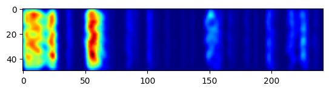

```python
from matplotlib import pyplot as plt
import numpy as np

png_path = '../GradCam/proximity/Classroom/80MHz/3mo/m1/Slots/Test_m1/A_batch/batch_1.png'

# Carregar a imagem
image = plt.imread(png_path)
# Exibir a imagem
plt.imshow(image)
```

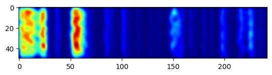

```python
npy_path = '../GradCam/proximity/Classroom/80MHz/3mo/m1/Slots/Test_m1/A_batch/batch_1.npy'

# Carregar o arquivo .npy
gradcam_data = np.load(npy_path)
# Exibir as chaves do dicionário
plt.imshow(gradcam_data,  cmap='jet')
```